# Test a Perceptual Phenomenon

### Analyzing the Stroop Effect

Perform the analysis in the space below. Remember to follow [the instructions](https://docs.google.com/document/d/1-OkpZLjG_kX9J6LIQ5IltsqMzVWjh36QpnP2RYpVdPU/pub?embedded=True) and review the [project rubric](https://review.udacity.com/#!/rubrics/71/view) before submitting. Once you've completed the analysis and write up, download this file as a PDF or HTML file and submit in the next section.

(1) What is the independent variable? What is the dependent variable?

Congruent and incongruent variables are conditions for the experiment, so they are independent; the response time is dependent variable.

(2) What is an appropriate set of hypotheses for this task? What kind of statistical test do you expect to perform? Justify your choices.

(3) Report some descriptive statistics regarding this dataset. Include at least one measure of central tendency and at least one measure of variability. The name of the data file is 'stroopdata.csv'.

```python
import pandas as pd
import numpy as np
from scipy import stats
data=pd.read_csv("stroopdata.csv")
a=np.mean(data['Congruent'])
b=np.mean(data['Incongruent'])
c=np.median(data['Congruent'])
d=np.median(data['Incongruent'])
e=stats.mode(data)
g=np.max(data['Congruent'])-np.min(data['Congruent'])
h=np.max(data['Incongruent'])-np.min(data['Incongruent'])
i=np.var(data['Congruent'])
j=np.var(data['Incongruent'])
k=np.std(data['Congruent'])
l=np.std(data['Incongruent'])
q75,q25=np.percentile(data['Congruent'],[75,25])
q2_75,q2_25=np.percentile(data['Incongruent'],[75,25])
iqr1=q75-q25
iqr2=q2_75-q2_25
g
h
i
j
k
l
iqr1
iqr2
e
```

```
ModeResult(mode=array([[  8.63 ,  15.687]]), count=array([[1, 1]]))
```

for congruent group, mean=14.0511, median=14.3565, range=13.6980, variance=12.1412, standard deviation=3.4844,interquantile range=4.3055 for incongruent group, mean=22.0160, median=21.0175, range=19.5680,variance=22.0529,standard deviation=4.6961,interquantile range=5.3347

(4) Provide one or two visualizations that show the distribution of the sample data. Write one or two sentences noting what you observe about the plot or plots.

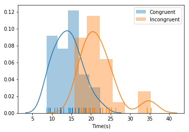

```python
import matplotlib.pyplot as plt
import seaborn as sns
import pandas as pd
data=pd.read_csv("stroopdata.csv")
sns.distplot(data['Congruent'],rug=True,label='Congruent')
sns.distplot(data['Incongruent'],rug=True,label='Incongruent')
plt.legend()
plt.xlabel('Time(s)');
```

(5) Now, perform the statistical test and report the results. What is the confidence level and your critical statistic value? Do you reject the null hypothesis or fail to reject it? Come to a conclusion in terms of the experiment task. Did the results match up with your expectations?

```python
# Perform t test
from scipy import stats
t,p=stats.ttest_rel(data['Congruent'],data['Incongruent'])
p
```

```
4.1030005857111781e-08
```

confidence level=0.95 t=-8.0207 Since p=4.103e-8<0.05, I have to reject the null hypothesis. Conclusion:Incongruent group takes significantly longer time than the congruent group. This matches up with my expectations. Because the interference can be explained by the automation of reading, where the mind automatically determines the semantic meaning of the word, and then must intentionally check itself and identify instead the color of the word , a process that is not automated.